# workshop.g-sh.tech

## О данных

Использованы данные форума [stackexchange](https://data.stackexchange.com/), хабы: datascience, AI, compmath

### Блок установок.

В случае, если не хватает какого-либо пакета -- этого должно хватить.

```python
! pip install plotly==2.5 gensim tqdm spacy pandas scikit-learn
```

```python
! python -m spacy download en
```

```python
! git clone https://github.com/facebookresearch/fastText.git
! pip install fastText/.
```

### Блок импортов

- логи + хотфикс для реализации ЛДА в gensim, иначе он неправильно утилизирует ядра

```python
import logging
logging.basicConfig(format='%(asctime)s : %(levelname)s : %(message)s', level=logging.INFO)

import os

os.environ['MKL_NUM_THREADS']='1'
os.environ['NUMEXPR_NUM_THREADS']='1'
os.environ['OMP_NUM_THREADS']='1'

import pandas as pd
import numpy as np

from string import punctuation, whitespace, digits
from collections import defaultdict
from itertools import chain, islice
import json

from tqdm import tqdm_notebook as tqdm
from tqdm import tqdm_pandas

from matplotlib import pyplot as plt
import seaborn as sns
import plotly.offline as py
import plotly.graph_objs as go
py.init_notebook_mode()

%matplotlib inline

from sklearn.decomposition import PCA
from sklearn.manifold import TSNE
from sklearn.cluster import DBSCAN, AgglomerativeClustering
from sklearn.ensemble import RandomForestClassifier
from sklearn.preprocessing import MultiLabelBinarizer
from sklearn.model_selection import cross_val_score
from sklearn.cross_validation import KFold
from sklearn.neighbors import KNeighborsClassifier, NearestNeighbors
from sklearn.metrics import recall_score, make_scorer, precision_score, roc_auc_score, jaccard_similarity_score
from sklearn.cross_validation import train_test_split

from scipy.spatial.distance import cosine

from gensim.matutils import sparse2full
from gensim.corpora import Dictionary
from gensim.models import LdaMulticore, FastText, TfidfModel

import fastText as vanilla_fastText
```

### Препроцессинг текстов

Обрабатываем тексты и чиним индексацию

# Не обязательно выпонять, ниже есть ячейка, где можно загрузить результат

```python
raw_posts = pd.read_json('./_shared/stackexchange_posts.jsonl', lines=True)
```

## Инициализация spaCy и обработка текстов вопросов

```python
import spacy
import re
import string

posts = raw_posts.copy()

cleanr = re.compile('<.*?>')
# cleanr = re.compile('<[^>]+>')

def strip_html(doc):
    cleantext = re.sub(cleanr, '', doc)
    #nopunct = "".join(l for l in cleantext if l not in string.punctuation)
    return cleantext #re.sub('\n', ' ', nopunct)

nlp = spacy.load('en')
nlp.remove_pipe('parser')
# nlp.remove_pipe('tagger')
nlp.remove_pipe('ner')


body_processed = []
for doc in tqdm(nlp.pipe(posts.Body.apply(strip_html), batch_size=500, )):
    body_processed.append([t.lemma_ for t in doc])

posts['body_processed'] = body_processed
```

### Обработка текстов ответов

```python
answers_processed = []

for answers in tqdm(posts.Answers.copy()):
    if answers is None:
        answers_processed.append(None)
        continue

    prepared_bodies = map(lambda x: strip_html(x['Body']), answers)
    bodies_processed = []
    for doc in nlp.pipe(prepared_bodies, batch_size=50):
        bodies_processed.append([t.lemma_ for t in doc])
    answers_processed.append(bodies_processed)

posts['answers_processed'] = posts.Answers.copy()

for_update = []

for i in tqdm(range(len(answers_processed))):
    if answers_processed[i] is None:
        for_update.append([])
        continue

    res = posts.Answers[i].copy()
    for j, processed_answer_body in enumerate(answers_processed[i]):
        res[j]['Body'] = processed_answer_body
    for_update.append(res)


posts.answers_processed = for_update
```

### Починка индексации

Поскольку мы смешали 3 хаба в датасет, ID стали не уникальны. Добавим номер хаба и сделаем их уникальными.

```python
hub2id = {name:i for i, name in enumerate(posts.Hub.unique())}

for n, (answers, hub) in posts[['answers_processed', 'Hub']].iterrows():
    if answers is None:
        continue
    for answer in answers:
        answer['Hub'] = hub
        answer['aId'] = answer['Id']*10 + hub2id[answer['Hub']]

posts['aId'] = posts.Id*10 + posts.Hub.map(hub2id.get)

posts.set_index('aId', inplace=True)

answers_df = pd.DataFrame(list(chain.from_iterable(filter(None, posts.answers_processed))))

answers_df.set_index('aId', inplace=True)
```

### Сохраняем результат

Эта часть почти не меняется, проще сохранить, чем пересчитывать

```python
posts.to_json('posts.processed.jsonl', orient='records', lines=True, force_ascii=False)
```

# Ниже ячейка с загрузкой обработанных фреймов

## Загружаем обработанное и работаем

```python
posts = pd.read_json('posts.processed.jsonl', lines=True)
answers_df = pd.DataFrame(list(chain.from_iterable(filter(None, posts.answers_processed))))
answers_df.set_index('aId', inplace=True)
raw_posts = pd.read_json('./_shared/stackexchange_posts.jsonl', lines=True)
```

```python
id2look = 0

print('='*120 + '\nQuestion text:')
print(posts.iloc[id2look]['Body'])
print('='*120 + '\nTags:\n')
print(posts.iloc[id2look]['Tags'])
print('='*120 + '\nProcessed:\n')
print(posts.iloc[id2look]['body_processed'])

print('='*120 + '\Processed answers:\n')
for i, answer_text in enumerate(posts.iloc[id2look].Answers):
    print('\t#%2s\t'%i + '*'*80)
    print('\t' + str(answer_text.get('Body')))
```

```
========================================================================================================================
Question text:
<p>What does "backprop" mean? I've Googled it, but it's showing backpropagation.</p>

<p>Is the "backprop" term basically the same as "backpropagation" or does it have a different meaning?</p>

========================================================================================================================
Tags:

<neural-networks><definitions><terminology>
========================================================================================================================
Processed:

['what', 'do', '"', 'backprop', '"', 'mean', '?', '-PRON-', 'have', 'google', '-PRON-', ',', 'but', '-PRON-', 'be', 'show', 'backpropagation', '.', '\n\n', 'be', 'the', '"', 'backprop', '"', 'term', 'basically', 'the', 'same', 'as', '"', 'backpropagation', '"', 'or', 'do', '-PRON-', 'have', 'a', 'di…
========================================================================================================================\Processed answers:

	# 0	********************************************************************************
	['"', 'backprop', '"', 'be', 'the', 'same', 'as', '"', 'backpropagation', '"', ':', '-PRON-', 'be', 'just', 'a', 'short', 'way', 'to', 'say', '-PRON-', '.', '-PRON-', 'be', 'sometimes', 'abbreviate', 'as', '"', 'bp', '"', '.', '\n']
	# 1	********************************************************************************
	['yes', ',', 'as', 'franck', 'have', 'rightly', 'put', ',', '"', 'backprop', '"', 'mean', 'backpropogation', ',', 'which', 'be', 'frequently', 'use', 'in', 'the', 'domain', 'of', 'neural', 'network', 'for', 'error', 'optimization', '.', '\n\n', 'for', 'a', 'detailed', 'explanation', ',', '-PRON-', …
	# 2	********************************************************************************
	["'", 'backprop', "'", 'be', 'short', 'for', "'", 'backpropagation', 'of', 'error', "'", 'in', 'order', 'to', 'avoid', 'confusion', 'when', 'use', 'backpropagation', 'term', '.', '\n\n', 'basically', 'backpropagation', 'refer', 'to', 'the', 'method', 'for', 'compute', 'the', 'gradient', 'of', 'the'…
```

### Вытащим только тексты из структуры для обучения языковых моделей

Также отделим тексты ответов и вопросов. И сохраним индексы правильных ответов

```python
just_texts = []

id2path = {}
current_pointer = 0

answers_texts = []
questions_texts = []

true_answers = defaultdict(list)

for n, (question, answers) in tqdm(posts[['body_processed', 'answers_processed']].iterrows()):
    just_texts.append(question)
    questions_texts.append(question)
    id2path[current_pointer] = ('post', n)
    current_pointer += 1
    just_texts.extend(_['Body'] for _ in answers)
    answers_texts.extend(_['Body'] for _ in answers)
    true_answers[len(questions_texts) - 1].extend(range(len(answers_texts) - len(answers), len(answers_texts)))
    for answer in answers:
        id2path[current_pointer] = ('ans', answer['aId'])
        current_pointer += 1
```

### Выше видно, что препроцессинг оставляет пунктуацию и структуру текста, функции ниже нам с этим помогут

```python
def is_trash_token(args, trash_is=punctuation+whitespace):
    if isinstance(args, tuple) or isinstance(args, list):
        args = args[0]
    token = args
    return all(map(lambda ch: ch in trash_is, token))

def is_trash_token_fragile(args, trash_is=punctuation+whitespace+'()+-/*$'):
    token = args
    return any(map(lambda ch: ch in trash_is, token))

def clean_token_fragile(args, trash_is=punctuation+whitespace+'()+-/*$'):
    token = args
    return ''.join(filter(lambda ch: ch not in trash_is, token))
```

## О модели

Фасттекст похож на word2vec, но еще и учитывает структуру слова. Оригинальный фасттект имеет возможность обучаться с учителем. Поскольку нам нужно предсказывать теги для вопроса, сразу воспользуемся этой функциональностью.

### Оригинальный фасттекст на вход получает файлы. Разобьем датасет на трейн и тест для проверки качества предсказания тегов.

```python
posts_train, posts_test = train_test_split(posts, test_size=0.1, random_state=42)

for set_name, dataset in [('train', posts_train), ('test', posts_test)]:
    with open('exchange.posts.fastext.%s.txt'%set_name, 'w') as outcome:
        for name, row in dataset.iterrows():
            outcome.write('%s %s %s\n'%(
                ' '.join(['__label__%s'%_.replace(whitespace, '_') for _ in row.Tags.replace('>', ' ').replace('<', ' ').split()]),
                ' '.join(clean_token_fragile(_) for _ in row.body_processed),
                ' '.join(clean_token_fragile(_) for _ in chain.from_iterable(map(lambda x: x['Body'], row.answers_processed)))
            ))
```

### Обучаем фасттекст

```python
%%time
v_fsttxt = vanilla_fastText.train_supervised(
    'exchange.posts.fastext.train.txt',
    dim=15,
    neg=400,
    minn=3,
    maxn=3,
    wordNgrams=10,
    t=0.005,
    lr=1,
    minCount=5,
    thread=6,
    loss='softmax',
#    pretrainedVectors='./_shared/wiki-news-300d-1M-subword.vec',
    ws=9,
    epoch=85)

def vanilla_embed_doc(doc, model=v_fsttxt):
    return v_fsttxt.get_sentence_vector(' '.join(clean_token_fragile(_) for _ in doc))
```

```
CPU times: user 13min 47s, sys: 1.85 s, total: 13min 49s
Wall time: 2min 22s
```

```python
%%time
v_fsttxt.quantize(
    'exchange.posts.fastext.train.txt',
    cutoff=300000,
    retrain=True,
    epoch=50,
    qnorm=True,
    lr=1,
    thread=6)
```

```
CPU times: user 9min 16s, sys: 3.24 s, total: 9min 19s
Wall time: 1min 48s
```

### И тут же пользуемся встроенной функциональностью для проверки качества

```python
print('Test size: %s; Prec: %3.3f; Rec: %3.3f'%v_fsttxt.test('exchange.posts.fastext.test.txt', k=3))
```

```
Test size: 1711; Prec: 0.305; Rec: 0.343
```

### С учетом того, что на 16 000 примеров в датасете почти 900 тегов, полученное качество впечатляет

### Построим индекс для поиска близких слов в пространстве фасттекста

И проверим, какие слова он считает близкими, и близки ли фразы, которые должны быть близки

```python
vwords_index = NearestNeighbors(algorithm='brute', metric='cosine')

vwords_index.fit([v_fsttxt.get_word_vector(_) for _ in v_fsttxt.get_words()])
```

```
NearestNeighbors(algorithm='brute', leaf_size=30, metric='cosine',
         metric_params=None, n_jobs=1, n_neighbors=5, p=2, radius=1.0)
```

```python
cosine(
    vanilla_embed_doc('what is backpropagation'.split()),
    vanilla_embed_doc('backpropagation is the same as backprob'.split()))
```

```
0.038128077983856201
```

```python
cosine(
    vanilla_embed_doc('what is backpropagation'.split()),
    vanilla_embed_doc('you should use backpropagation for training your models'.split()))
```

```
0.16924434900283813
```

### Действительно, фраза, похожая на ответ имеет меньшее расстояние

### Попробуем, как работают аналогия и синонимы

```python
word2check = 'nlp'


wdists, wids = vwords_index.kneighbors([v_fsttxt.get_word_vector(word2check)], n_neighbors=20)
print('\n'.join('%3.3f\t %s'%(wdist, v_fsttxt.f.getVocab()[0][wid]) for wdist, wid in zip(wdists[0], wids[0]) if wid < len(v_fsttxt.get_words())))
```

```
0.000	 nlp
0.070	 nlg
0.079	 nl
0.180	 anisotropic
0.188	 corenlp
0.198	 textblob
0.202	 gazetteer
0.218	 loebner
0.223	 institution
0.238	 my
0.240	 demonstration
0.241	 chatbot
0.241	 ship
0.246	 stl
0.247	 apple
0.254	 isotropic
0.256	 constituency
0.256	 ownership
0.259	 tube
0.260	 minlp
```

```python
word2check = 'classification'


wdists, wids = vwords_index.kneighbors([v_fsttxt.get_word_vector(word2check)], n_neighbors=20)
print('\n'.join('%3.3f\t %s'%(wdist, v_fsttxt.f.getVocab()[0][wid]) for wdist, wid in zip(wdists[0], wids[0]) if wid < len(v_fsttxt.get_words())))
```

```
0.000	 classification
0.057	 classifier
0.132	 classify
0.156	 misclassification
0.163	 knn
0.170	 misclassifi
0.173	 classroom
0.193	 mlpclassifier
0.214	 universal
0.227	 clarify
0.231	 sigmoid
0.255	 union
0.262	 sky
0.266	 fat
0.267	 seidel
0.271	 classic
0.275	 onevsrestclassifi
0.276	 classical
0.278	 univariate
0.280	 universe
```

### Попробуем построить "путь" в пространстве смыслов от одного слова к другому

```python
word_vector_from = v_fsttxt.get_word_vector('classification')
word_vector_to = v_fsttxt.get_word_vector('model')
```

```python
tot = 10
for i in range(tot+1):
    dist, wordid = vwords_index.kneighbors([((i*word_vector_to + (tot-i)*word_vector_from)/tot)], n_neighbors=1)
    print('%0.4f\t'%dist[0][0], v_fsttxt.f.getVocab()[0][wordid[0, 0]])
```

```
0.0000	 classification
0.0143	 classification
0.0642	 classification
0.1236	 classifier
0.1845	 delivery
0.1418	 model
0.0736	 model
0.0333	 model
0.0120	 model
0.0024	 model
0.0000	 model
```

### Посмотрим, как модель выставляет теги

```python
id2look = 1

tags = '#'+', #'.join(v_fsttxt.predict(' '.join(posts_test.iloc[id2look].body_processed).replace('\n', ' '), k=5)[0])
print(tags)
print('='*len(tags))
print(posts_test.iloc[id2look].Body.replace('<p>','').replace('</p>', '\n'))
print(posts_test.iloc[id2look].Tags)
```

```
#__label__text-mining, #__label__unsupervised-learning, #__label__clustering, #__label__nlp, #__label__classification
=====================================================================================================================
My <strong>goal</strong> is to get a <strong>smartphone names</strong> from Twitter. So this is what I followed:


1- I extracted 100K tweets using the keyword “smartphone”.


2- I Applied LDA after applying ngram tokenization and cleaning.So, I got noisy results such as:(giveway, international, apple, iphone_6, samsung_s5,news…)


3- I filtered the results using a smartphone list (iphone_6, samsung_s5,iphone_4s,…) extracted from DBpedia in order to remove the noise.<br><br>
Is what I did supervised or unsupervised Machine learning?


<machine-learning><supervised-learning><topic-model><unsupervised-learning><lda>
```

### Интересно, как выглядят документы в семантическом пространстве

```python
to_draw_num = 3000

vecs = np.array(list(vanilla_embed_doc(_) for _ in tqdm(just_texts[:to_draw_num])))

# clusterizer = DBSCAN(metric='cosine', p=1, n_jobs=1, eps=0.08, min_samples=5, algorithm='brute')
clusterizer = AgglomerativeClustering(n_clusters=200, affinity='cosine', linkage='complete')
clusters = clusterizer.fit_predict(vecs[:to_draw_num])

proj = TSNE(2)
vecs2draw = proj.fit_transform(vecs[:to_draw_num])
```

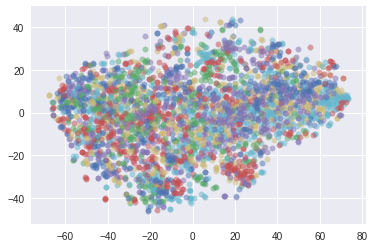

```python
plt.figure(figsize=(6,4))
for cluster_id in set(clusters) - set([-1]):
    plt.scatter(vecs2draw[clusters == cluster_id, 0], vecs2draw[clusters == cluster_id, 1], s=30, alpha=0.5, label='%s cl'%cluster_id)

plt.scatter(vecs2draw[clusters == -1, 0], vecs2draw[clusters == -1, 1], s=10, c='lightblue', alpha=0.5, label='unlabeled')
# plt.legend()
```

### код ниже построит интерактивную визуализацию(тяжелая, может повесить браузер на старой машине)

```python
def get_repr_of(id_to_repr):
    index_type, index_id = id2path[id_to_repr]
    if index_type == 'post':
        return '[%s] post[sc: %s]: %s'%(index_id, posts.loc[index_id].Score, posts.loc[index_id].Title)
    elif index_type == 'ans':
        words = answers_df.loc[index_id].Body
        return '[%s] ans[sc: %s]: %s'%(index_id, answers_df.loc[index_id].Score, ' '.join(words[:min(10, len(words))]))
    else:
        raise Exception()

colors = [ 'red' if id2path[_][0] == 'post' else 'green' for _ in range(vecs2draw.shape[0])]

topic_labels = [get_repr_of(_) for _ in tqdm(range(vecs2draw.shape[0]))]
```

```python
#### colors = ['hsl({}, 70%, 50%)'.format((43 * hash(row)) % 360) for row in topic_labels]

trace = go.Scatter(
    x = vecs2draw[:, 0],
    y = vecs2draw[:, 1],
    text = topic_labels,
    mode = 'markers',
    marker=dict(size=4, color=colors, opacity=0.3),
)

py.iplot([trace])
```

## Проверим поисковые возможности модели

```python
from sklearn.neighbors import NearestNeighbors
```

### Обучим индекс на эмбеддингах ответов

Ведь мы хотим найти ответы на вопросы: значит в индесе должны быть именно ответы

```python
indexer = NearestNeighbors(n_neighbors=20, metric='cosine', p=1, algorithm='brute', n_jobs=1)

indexer.fit(list(vanilla_embed_doc(_) for _ in tqdm(answers_texts)))
```

```
NearestNeighbors(algorithm='brute', leaf_size=30, metric='cosine',
         metric_params=None, n_jobs=1, n_neighbors=20, p=1, radius=1.0)
```

### Построим вектора для вопросов и сразу опросим индекс

```python
num_questions = 10000

dists, names = indexer.kneighbors(
    list(vanilla_embed_doc(_) for _ in tqdm(questions_texts[:num_questions])),
    n_neighbors=5)
```

```python
for (name, question), dist_to, name_ids in zip(islice(raw_posts.iterrows(), 5), dists, names):
    print(question.Body)
    for dist, name in zip(dist_to, name_ids):
        print('\t %s, %s'%(dist, ', '.join(_.strip() for _ in answers_texts[name])))
```

```
<p>What does "backprop" mean? I've Googled it, but it's showing backpropagation.</p>

<p>Is the "backprop" term basically the same as "backpropagation" or does it have a different meaning?</p>

	 0.155379, ", backprop, ", be, the, same, as, ", backpropagation, ", :, -PRON-, be, just, a, short, way, to, say, -PRON-, ., -PRON-, be, sometimes, abbreviate, as, ", bp, ", .,
	 0.200711, this, be, a, very, interesting, question, and, also, an, important, one, for, ai, ., all, the, current, deep, learning, success, be, build, on, the, effectiveness, of, backprop, ,, so, what, if, -PRON-, do, not, play, a, role, in, the, only, example, of, intelligence, currently, around, …
	 0.210159, the, full, answer, to, -PRON-, question, be, yes, and, no, ., let, -PRON-, elaborate, :, , yes, ,, -PRON-, can, train, such, a, model, with, sgd, :, , yes, ,, -PRON-, can, train, a, model, like, -PRON-, describe, ., this, be, well, know, under, the, name, ", autoencoder, ", ., the, goal,…
	 0.220227, regard, ", mimic, human, intelligence, ", --, >, no, ,, not, even, close, ., , regard, this, :, , can, the, entire, field, be, sum, -, up, in, this, one, sentence, ?, ", neural, networks, use, the, sigmoid, function, and, gradient, descent, to, fine, -, tune, weight, ., ", , no, ,, again…
	 0.239045, for, learn, kernel, /, filter, matrix, in, convolution, layer, ,, -PRON-, find, partial, derivative, of, loss, w.r.t, ., filter, matrix, and, use, gradient, descent, method, to, update, filter, ., , $, $, w, =, w, -, \alpha\frac{\partial, l}{\partial, w, }, $, $, , convolutional, neural,…
<p>Does increasing the noise in data help to improve the learning ability of a network? Does it make any difference or does it depend on the problem being solved? How is it affect the generalization process overall?</p>

	 0.14319, with, dropout, ,, the, sum, of, activation, feed, each, neuron, during, training, and, testing, need, to, be, roughly, the, same, ., the, problem, be, that, during, train, some, neuron, be, mask, out, ,, and, this, do, not, happen, during, testing, ., therefore, there, have, to, be, a, sc…
	 0.157276, -PRON-, find, both, of, -PRON-, option, slightly, faulty, ., so, ,, this, be, generally, (, very, broadly, ), how, a, predictive, modelling, workflow, look, like, :, , datum, cleaning, :, take, the, most, time, ,, but, every, second, spend, here, be, worth, -PRON-, ., the, clean, -PRON-,…
	 0.170254, here, be, -PRON-, understanding, :, , -PRON-, think, -PRON-, be, the, explanation, of, page, 10, ,, and, time, be, the, same, as, the, ", time, ", in, page, 10, ,, which, mean, the, time, axis, in, real, life, ., , in, page, 10, ,, -PRON-, show, that, :, , hold, out, datum, should, be, o…
	 0.177258, this, be, an, error, in, orange, 3.3.11, ,, and, fix, in, release, 3.3.12, ., update, to, the, new, release, to, get, rid, of, the, error, .,
	 0.186743, first, of, all, ,, -PRON-, should, say, that, a, single, affine, layer, of, a, neural, network, without, any, non, -, linearity, /, activation, be, practically, the, same, as, a, linear, model, ., here, -PRON-, be, refer, to, deep, neural, network, that, have, multiple, layer, and, activ…
<p>When you're writing your algorithm, how do you know how many neurons you need per single layer? Are there any methods for finding the optimal number of them, or is it a rule of thumb?</p>

	 0.132109, no, ., , map, reduce, by, definition, work, at, one, record, at, a, time, ., , thus, ,, -PRON-, can, not, compute, a, distance, /, similarity, matrix, without, abuse, the, programming, model, ., method, such, as, svm, do, require, pairwise, similarity, ., , such, abuse, be, really, commo…
	 0.148954, mct, for, chess, have, be, try, in, the, literature, with, little, success, ., -PRON-, be, assume, alphago, 's, approach, would, never, work, on, chess, ,, maybe, in, go, but, not, in, chess, ., suddenly, ,, google, announce, the, approach, be, work, and, -PRON-, be, beat, the, world, 's…
	 0.150863, the, software, that, -PRON-, require, to, provide, -PRON-, ai, agent, remote, access, be, call, virtual, network, computing, (, vnc, ), ., a, vnc, be, a, desktop, sharing, system, that, transmit, keyboard, and, mouse, movement, ,, over, a, network, connection, ,, from, the, server, (, th…
	 0.152349, deep, neural, network, ,, probably, with, ten, of, internal, layer, ,, distribute, across, many, many, machine, ., each, user, probably, receive, score, from, many, deep, network, for, various, application, ,, and, each, network, be, probably, automatically, score, to, determine, when, -…
	 0.159502, aws, do, ", support, ", mac, os, ., -PRON-, can, use, any, ssh, client, from, -PRON-, mac, to, access, the, gpu, instance, .,
<p>I have a LEGO Mindstorms EV3 and I'm wondering if there's any way I could start coding the bot in Python rather than the default drag-and-drop system. Is a Mindstorm considered AI?</p>

<p>Is this possible?</p>

<hr>

<p>My goal is to write a basic walking program in Python. The bot is the EV3RSTORM. I searched and found <a href="http://bitsandbricks.no/2014/01/19/getting-started-with-python-on-ev3/" rel="nofollow">this</a>, but don't understand it. </p>
```

[output cut: 15 more lines]

### Посчитаем относительное количество совпадений с настоящими ответами

```python
def recall(predicted, true):
    if not len(true):
        return 0.001
    return len(set(predicted) & set(true))/len(true)

def precision(predicted, true):
    if not len(predicted):
        return 0.001
    return len(set(predicted) & set(true))/len(predicted)

def jaccard(predicted, true):

    return len(set(true) & set(predicted))/len(set(true) | set(predicted))
```

```python
jaccards = []


for i, found in (enumerate(names)):
    jaccards.append(
        (
            jaccard(found, true_answers[i]),
            precision(found, true_answers[i]),
            recall(found, true_answers[i])
        )
    )
```

```python
np.array(jaccards).std(axis=0)
```

```
array([ 0.03434974,  0.03734672,  0.26317482])
```

```python
np.array(jaccards).mean(axis=0)
```

```
array([ 0.01237438,  0.01335   ,  0.09088019])
```

## Не очень круто, но конечно под поиск стоит тюнить специальную модель

### Еще можно на глаз оценить способность модели находить очень похожие вопросы

Для этого обучим индекс на векторах вопросов

```python
indexer = NearestNeighbors(n_neighbors=20, metric='cosine', p=1, algorithm='brute', n_jobs=1)

indexer.fit(list(vanilla_embed_doc(_) for _ in tqdm(questions_texts)))
```

```
NearestNeighbors(algorithm='brute', leaf_size=30, metric='cosine',
         metric_params=None, n_jobs=1, n_neighbors=20, p=1, radius=1.0)
```

... и поищем по векторам вопросов

```python
num_questions = 10

dists, names = indexer.kneighbors(
    list(vanilla_embed_doc(_) for _ in tqdm(questions_texts[:num_questions])),
    n_neighbors=3)
```

```python
for (name, question), dist_to, name_ids in zip(islice(raw_posts.iterrows(), 5), dists, names):
    print(question.Body)
    for dist, name in zip(dist_to, name_ids):
        print('\t %s, %s\n'%(dist, ', '.join(_.strip() for _ in questions_texts[name])))
```

[output not shown]

#### И просто статистика о количестве и частоте тегов

```python
tags_counter = Counter(chain.from_iterable(posts.Tags.map(lambda x: x.replace('>', ' ').replace('<', ' ').split())))

hist = np.array(list(map(lambda x: x[-1], tags_counter.items())))

tags = np.array(list(map(lambda x: x[0], tags_counter.items())))
```

```python
tags = tags[np.argsort(hist)][::-1]
hist = hist[np.argsort(hist)][::-1]
```